# Reproducible Research: Peer Assessment 1

## Global setting

```r
echo = TRUE  # Always make code visible
```

## Loading and preprocessing the data

Download, extract and store the data in the mydata data frame. Also transform the date field to Date format and omit NAs.

```r
fileUrl <- "https://d396qusza40orc.cloudfront.net/repdata%2Fdata%2Factivity.zip"
download.file(fileUrl,destfile="DataActivity.zip", method="curl")
unzip("DataActivity.zip")
mydata <- na.omit(read.csv("./activity.csv", colClasses = c("integer", "Date", "integer")))
```

A histogram of the total number of steps taken each day is calculated and shown below:

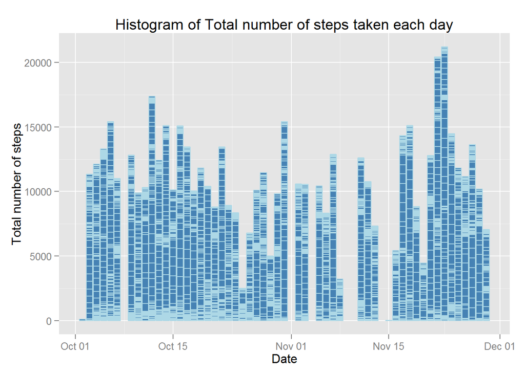

```r
library("ggplot2")

ggplot(mydata, aes(date, steps)) +
  geom_bar(stat="identity", fill="steelblue", colour="lightblue") +
  labs(x="Date") +
  labs(y="Total number of steps") +
  labs(title="Histogram of Total number of steps taken each day")
```

```r
library(dplyr)
summary <- summarize(group_by(mydata,date),mean=mean(steps), median=median(steps))
```

## What is the average daily activity pattern?

Make a time series plot (i.e. type = “l”) of the 5-minute interval (x-axis) and the average number of steps taken, averaged across all days (y-axis)

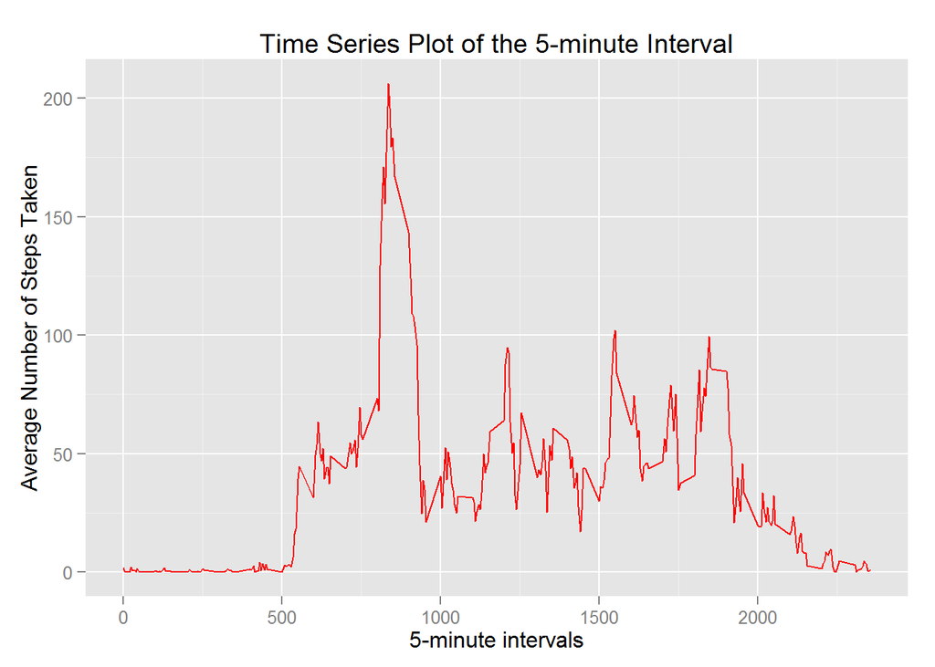

```r
stats<-summarize(group_by(mydata,interval),mean=mean(steps))
ggplot(stats, aes(interval, mean)) +
  geom_line(color="red") +
  labs(x="5-minute intervals") +
  labs(y="Average Number of Steps Taken") +
  labs(title="Time Series Plot of the 5-minute Interval")
```

Which 5-minute interval, on average across all the days in the dataset, contains the maximum number of steps?

```r
stats[stats$mean == max(stats$mean), ]
```

```
## Source: local data frame [1 x 2]
##
##   interval     mean
## 1      835 206.1698
```

## Imputing missing values

The total number of rows with NAs:

```r
sum(is.na(read.csv("./activity.csv", colClasses = c("integer", "Date", "integer"))))
```

```
## [1] 2304
```

Devise a strategy for filling in all of the missing values in the dataset. The strategy does not need to be sophisticated. For example, you could use the mean/median for that day, or the mean for that 5-minute interval, etc. * My strategy is to use the mean for that 5-minute interval to fill each NA value in the steps column.

Create a new dataset that is equal to the original dataset but with the missing data filled in.

```r
mydata_w_na <- read.csv("./activity.csv", colClasses = c("integer", "Date", "integer"))
myfixed <- merge(mydata_w_na, stats, by="interval", type="inner")
myfixed$new_steps <- ifelse(is.na(myfixed$steps), myfixed$mean, myfixed$steps)
myfixed <- select(myfixed, date, interval, new_steps)
sum(is.na(myfixed)) #Check if NAs got eliminated
```

```
## [1] 0
```

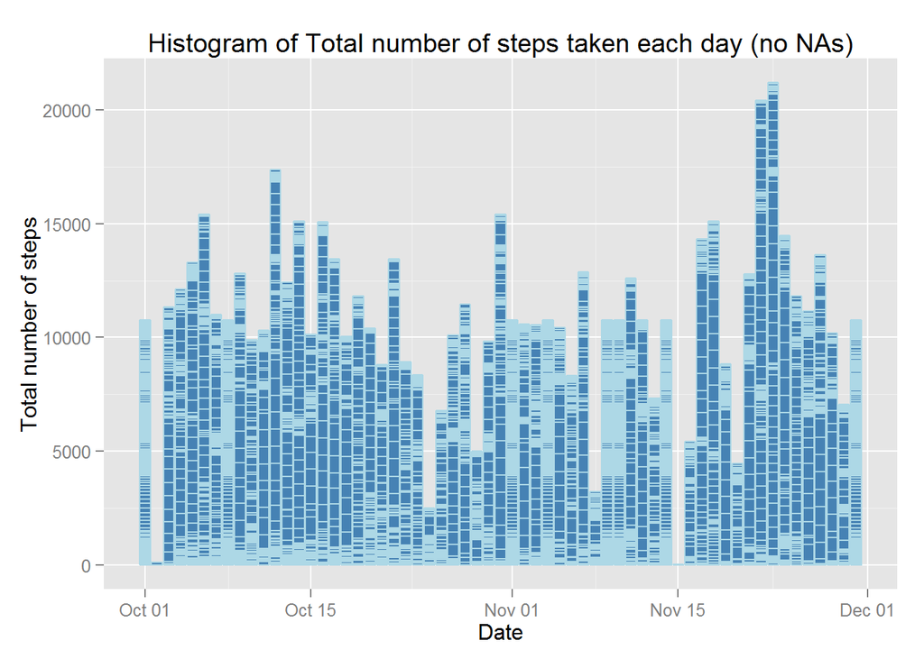

```r
ggplot(myfixed, aes(date, new_steps)) +
  geom_bar(stat="identity", fill="steelblue", colour="lightblue") +
  labs(x="Date") +
  labs(y="Total number of steps") +
  labs(title="Histogram of Total number of steps taken each day (no NAs)")
```

```r
summary_new <- summarize(group_by(myfixed,date),mean=mean(new_steps), median=median(new_steps))
```

## Are there differences in activity patterns between weekdays and weekends?

Append “Weekend” or “Weekday” to a new field, conditionally.

```r
myfixed$day<-as.factor(ifelse(weekdays(myfixed$date) %in% c("Saturday","Sunday"),"Weekend","Weekday"))
```

Plot the 5-minute average of steps, by weekday/weekend.

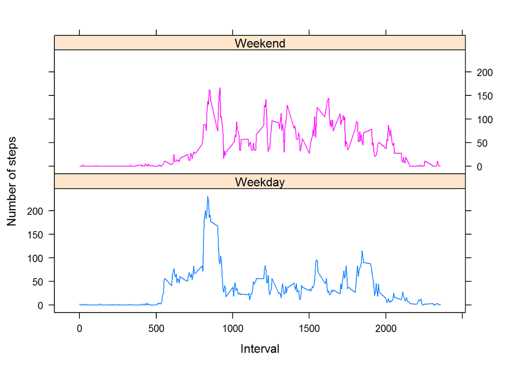

```r
summary_day <- summarize(group_by(myfixed,day,interval), mean=mean(new_steps))
library(lattice)
xyplot(mean~interval | day, data=summary_day, layout=c(1, 2), type="l", xlab="Interval", ylab="Number of steps", group=day)
```